# Personality-analysis

2025-06-25

**Khai báo Thư viện**

```r
library(reshape2)
library(ggplot2)
```

**Đọc dữ liệu**

```r
data <- read.csv("E:/Học Tập/Đại Học/Năm 4 HK 2 2024-2025/thống kê nhiều chiều/thong_ke_chieu_chieu/PROJECT/DATA/personality_synthetic_dataset.csv", header = TRUE, stringsAsFactors = TRUE)
```

**Thông tin tổng quan của bộ dữ liệu**

```r
head(data, 10)
```

```
##    personality_type social_energy alone_time_preference talkativeness
## 1         Extrovert      6.794295              3.854670      8.725446
## 2          Ambivert      6.378988              5.731157      7.029529
## 3          Ambivert      7.459421              6.322263      3.922269
## 4         Extrovert      6.159626              3.097837      6.019093
## 5         Introvert      5.568462              6.986722      3.913240
## 6         Introvert      2.807173              6.326097      2.770085
## 7         Introvert      1.537468              7.605496      4.294666
## 8          Ambivert      6.636632              4.350586      7.131511
## 9         Extrovert      7.330318              2.820421      5.224400
## 10         Ambivert      5.377395              4.762184      4.244447
##    deep_reflection group_comfort party_liking listening_skill  empathy
## 1         2.515151      7.097368    8.5887616        6.774799 6.430132
## 2         7.274493      4.111199    3.2582475        5.550909 3.958179
## 3         4.622261      5.343276    7.4521522        9.483990 6.127654
```

[output cut: 62 more lines]

```r
# Kiểm tra số chiều của dữ liệu
dim(data)
```

```
## [1] 20000    30
```

Bộ dữ liệu tổng hợp này được thiết kế để mô phỏng các loại tính cách của con người — Hướng nội, Hướng ngoại và cả người có cả hướng ngoại lẫn hướng nội — dựa trên nhiều đặc điểm hành vi và tâm lý khác nhau.

Bộ dữ liệu này chứa 20.000 mục nhập và 30 cột, bao gồm 29 đặc điểm số biểu thị các chỉ số tính cách và 1 cột nhãn (personality_type).

Trong đó

- personality_type: biến mục tiêu gồm 3 kiểu tính cách: Introvert(hướng nội), Extrovert(hướng ngoại), or Ambivert (hỗn hợp).
- social_energy: Xu hướng đón nhận năng lượng từ tương tác xã hội (0–10).
- alone_time_preference: thể hiện sự thoải mái với sự cô đơn.
- talkativeness: Xu hướng tham gia và các cuộc trò chuyện.
- deep_reflection: Tần suất suy nghĩ sâu hoặc suy nghĩ nội tâm.
- group_comfort: Dễ hoà nhập với các nhóm/ hội.
- party_liking: Sự thích thú đối với các bữa tiệc và các sự kiện.
- listening_skill: Khả năng lắng nghe
- empathy: khả năng đồng cảm hay thấu hiểu cảm xúc của người khác.
- creativity: sự tư duy sáng tạo.
- organization: Mức độ ưu tiên cho các trật tự, kế hoạch.
- leadership: Sự thoải mái khi làm lãnh đạo.
- risk_taking: Sự chấp nhận rủi ro.
- public_speaking_comfort: Mức độ thoải mái khi nói chuyện trước đám đông hoặc công chúng.
- curiosity: Mức độ thích học tập và khám phá những cái mới.
- routine_preference: Thể hiện thói quen và sự tự phát.
- excitement_seeking: Mức độ mong muốn những trải nghiệm mới mẻ.
- friendliness: Mức độ thân thiện.
- emotional_stability: Khả năng kiểm soát và cân bằng khi căng thẳng.
- planning: Xu hướng lập kế hoạch từ trước.
- spontaneity: Hành động tự phát không có kế hoạch từ trước.
- adventurousness: Sẵn sàng thử những hoạt động mới và mạo hiểm.
- reading_habit: Tần suất đọc sách báo.
- sports_interest: Mức độ quan tâm tới thể thao hoặc các hoạt động thể chất.
- online_social_usage: Thời gian dành cho mạng xã hội.
- travel_desire: Sở thích du lịch và khám phá những địa điểm mới.
- gadget_usage: Tần suất sử dụng các thiết bị công nghệ và tiện ích.
- work_style_collaborative: mức độ làm việc nhóm so với với việc làm cá nhân.
- decision_speed: Thời gian đưa ra các quyết định.
- stress_handling: Khả năng quản lý căng thẳng cách hiệu quả.

**Khảo sát dữ liệu**

```r
str(data)
```

```
## 'data.frame':    20000 obs. of  30 variables:
##  $ personality_type        : Factor w/ 3 levels "Ambivert","Extrovert",..: 2 1 1 2 3 3 3 1 2 1 ...
##  $ social_energy           : num  6.79 6.38 7.46 6.16 5.57 ...
##  $ alone_time_preference   : num  3.85 5.73 6.32 3.1 6.99 ...
##  $ talkativeness           : num  8.73 7.03 3.92 6.02 3.91 ...
##  $ deep_reflection         : num  2.52 7.27 4.62 1.97 9.93 ...
##  $ group_comfort           : num  7.1 4.11 5.34 7.84 1.65 ...
##  $ party_liking            : num  8.589 3.258 7.452 10 0.362 ...
##  $ listening_skill         : num  6.77 5.55 9.48 9.44 7.47 ...
##  $ empathy                 : num  6.43 3.96 6.13 8.95 6.76 ...
##  $ creativity              : num  6.14 6.15 7.03 8.92 9.51 ...
##  $ organization            : num  0 4.53 7.09 5.23 6.38 ...
##  $ leadership              : num  8.49 6.21 3.03 10 4.45 ...
##  $ risk_taking             : num  6.89 4.88 4.31 8.2 2.46 ...
##  $ public_speaking_comfort : num  8.62 5.02 6.47 7.27 2.78 ...
```

[output cut: 16 more lines]

Nhận xét: Các biến đều có giá trị numeric. Chỉ có biến “personality_type” là biến mục tiêu.

```r
summary(data)
```

```
##   personality_type social_energy    alone_time_preference talkativeness
##  Ambivert :6573    Min.   : 0.000   Min.   : 0.000        Min.   : 0.000
##  Extrovert:6857    1st Qu.: 3.591   1st Qu.: 3.510        1st Qu.: 3.596
##  Introvert:6570    Median : 5.541   Median : 5.464        Median : 5.575
##                    Mean   : 5.509   Mean   : 5.455        Mean   : 5.526
##                    3rd Qu.: 7.424   3rd Qu.: 7.416        3rd Qu.: 7.472
##                    Max.   :10.000   Max.   :10.000        Max.   :10.000
##  deep_reflection  group_comfort     party_liking    listening_skill
##  Min.   : 0.000   Min.   : 0.000   Min.   : 0.000   Min.   : 1.308
##  1st Qu.: 4.383   1st Qu.: 4.416   1st Qu.: 2.728   1st Qu.: 5.813
##  Median : 5.972   Median : 6.051   Median : 5.053   Median : 6.990
##  Mean   : 5.959   Mean   : 6.014   Mean   : 5.040   Mean   : 6.964
##  3rd Qu.: 7.598   3rd Qu.: 7.669   3rd Qu.: 7.364   3rd Qu.: 8.156
##  Max.   :10.000   Max.   :10.000   Max.   :10.000   Max.   :10.000
##     empathy          creativity      organization      leadership
##  Min.   : 0.8049   Min.   : 0.000   Min.   : 0.000   Min.   : 0.000
##  1st Qu.: 5.4485   1st Qu.: 4.993   1st Qu.: 4.806   1st Qu.: 4.441
##  Median : 6.4814   Median : 6.003   Median : 5.987   Median : 6.043
##  Mean   : 6.4832   Mean   : 5.996   Mean   : 5.973   Mean   : 6.020
##  3rd Qu.: 7.5215   3rd Qu.: 7.013   3rd Qu.: 7.142   3rd Qu.: 7.649
##  Max.   :10.0000   Max.   :10.000   Max.   :10.000   Max.   :10.000
##   risk_taking     public_speaking_comfort   curiosity       routine_preference
##  Min.   : 0.000   Min.   : 0.000          Min.   : 0.6422   Min.   : 0.000
##  1st Qu.: 3.428   1st Qu.: 3.614          1st Qu.: 5.4595   1st Qu.: 4.094
##  Median : 5.012   Median : 5.535          Median : 6.4984   Median : 5.471
##  Mean   : 5.012   Mean   : 5.512          Mean   : 6.5038   Mean   : 5.453
##  3rd Qu.: 6.602   3rd Qu.: 7.442          3rd Qu.: 7.5652   3rd Qu.: 6.817
##  Max.   :10.000   Max.   :10.000          Max.   :10.0000   Max.   :10.000
##  excitement_seeking  friendliness     emotional_stability    planning
##  Min.   : 0.000     Min.   : 0.9932   Min.   : 0.4373     Min.   : 0.000
##  1st Qu.: 3.604     1st Qu.: 5.8432   1st Qu.: 5.0101     1st Qu.: 4.832
##  Median : 5.545     Median : 6.9980   Median : 6.0265     Median : 5.981
##  Mean   : 5.529     Mean   : 6.9757   Mean   : 6.0158     Mean   : 5.993
##  3rd Qu.: 7.502     3rd Qu.: 8.1747   3rd Qu.: 7.0241     3rd Qu.: 7.167
##  Max.   :10.000     Max.   :10.0000   Max.   :10.0000     Max.   :10.000
##   spontaneity     adventurousness  reading_habit    sports_interest
##  Min.   : 0.000   Min.   : 0.000   Min.   : 0.000   Min.   : 0.000
##  1st Qu.: 4.156   1st Qu.: 3.429   1st Qu.: 4.325   1st Qu.: 4.127
##  Median : 5.500   Median : 5.045   Median : 5.963   Median : 5.508
##  Mean   : 5.495   Mean   : 5.034   Mean   : 5.941   Mean   : 5.492
##  3rd Qu.: 6.853   3rd Qu.: 6.656   3rd Qu.: 7.565   3rd Qu.: 6.861
##  Max.   :10.000   Max.   :10.000   Max.   :10.000   Max.   :10.000
##  online_social_usage travel_desire     gadget_usage    work_style_collaborative
##  Min.   : 0.000      Min.   : 0.000   Min.   : 0.000   Min.   : 0.000
##  1st Qu.: 5.158      1st Qu.: 4.155   1st Qu.: 4.868   1st Qu.: 5.161
##  Median : 6.529      Median : 5.499   Median : 6.007   Median : 6.526
##  Mean   : 6.499      Mean   : 5.509   Mean   : 6.007   Mean   : 6.502
##  3rd Qu.: 7.885      3rd Qu.: 6.877   3rd Qu.: 7.161   3rd Qu.: 7.879
##  Max.   :10.000      Max.   :10.000   Max.   :10.000   Max.   :10.000
##  decision_speed   stress_handling
##  Min.   : 0.000   Min.   : 0.000
##  1st Qu.: 4.150   1st Qu.: 4.973
##  Median : 5.528   Median : 5.979
##  Mean   : 5.516   Mean   : 5.982
##  3rd Qu.: 6.906   3rd Qu.: 6.991
##  Max.   :10.000   Max.   :10.000
```

Nhận xét: Ta thấy bộ dữ liệu này khảo sát với số lượng người thuộc từng nhóm ~ nhau:

**Kiểm tra giá trị bị thiếu**

```r
missing_values <- colSums(is.na(data))
print(missing_values)
```

```
##         personality_type            social_energy    alone_time_preference
##                        0                        0                        0
##            talkativeness          deep_reflection            group_comfort
##                        0                        0                        0
##             party_liking          listening_skill                  empathy
##                        0                        0                        0
##               creativity             organization               leadership
##                        0                        0                        0
##              risk_taking  public_speaking_comfort                curiosity
##                        0                        0                        0
##       routine_preference       excitement_seeking             friendliness
##                        0                        0                        0
##      emotional_stability                 planning              spontaneity
##                        0                        0                        0
##          adventurousness            reading_habit          sports_interest
##                        0                        0                        0
##      online_social_usage            travel_desire             gadget_usage
##                        0                        0                        0
## work_style_collaborative           decision_speed          stress_handling
##                        0                        0                        0
```

Nhận xét: Bộ dữ liệu không có giá trị nào bị thiếu.

**Ta lấy các cột biến để thực hiện PCA (trừ biến personality_type)**

```r
numeric_data <- data[, -1]
```

**Vẽ boxplot**

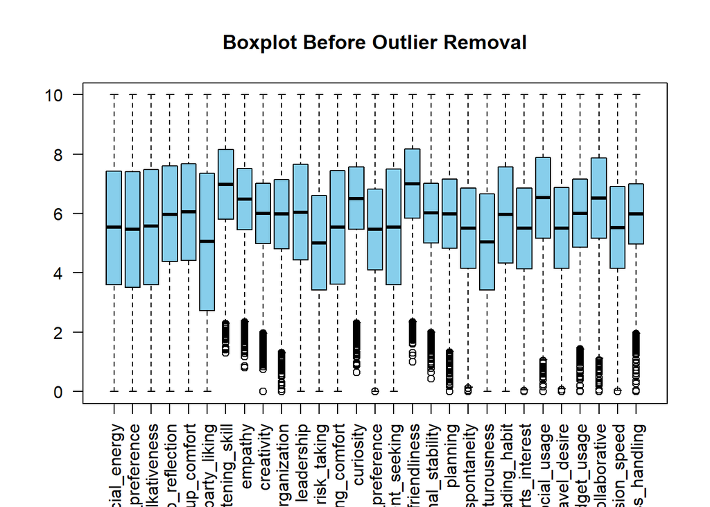

```r
boxplot(numeric_data, main = "Boxplot Before Outlier Removal", las = 2, col = "skyblue")
```

Nhận xét: Ta nhận thấy có các giá trị ngoại lai ở một số biến.

**Kiểm tra giá trị ngoại lai và tiến hành xử lý**

Vì đây là bộ dữ liệu nhiều chiều nên không thể sử dụng IQR để xác định các giá trị ngoại lai mà cần sử dụng khoảng cách Mahalanobis để xác định các giá trị ngoại lai.

```r
mahalanobis_distance <- mahalanobis(numeric_data, colMeans(numeric_data), cov(numeric_data))
cutoff_value <- qchisq(0.95, df = ncol(numeric_data)) # 95% quantile for chi-square distribution
outliers <- which(mahalanobis_distance > cutoff_value)
```

In số lượng ngoại lai và tính tỉ lệ ngoại lai trong bộ dữ liệu

```r
cat("số lượng ngoại lai:", length(outliers), "\n")
```

```
## số lượng ngoại lai: 821
```

```r
cat("Tỷ lệ ngoại lai:", length(outliers)/nrow(data)*100, "%", "\n")
```

```
## Tỷ lệ ngoại lai: 4.105 %
```

Nhận xét: có 821 giá trị ngoại lai chiếm 4,105% giá trị quan trắc bộ dữ liệu. Vì số lượng ngoại lai không lớn nên ta tiến hành loại bỏ các giá trị này.

Loại bỏ các giá trị ngoại lai.

```r
data_no_outliers <- numeric_data[-outliers, ]
```

Vẽ lại boxplot sau khi loại bỏ các giá trị ngoại lai

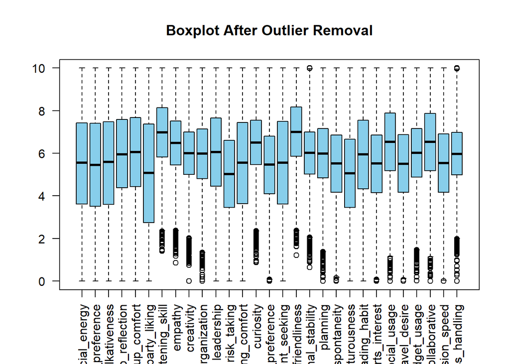

```r
boxplot(data_no_outliers, main = "Boxplot After Outlier Removal", las = 2, col = "skyblue")
```

Nhận xét: mặc dù có thể thấy vẫn còn nhiều giá trị ngoại lai, nhưng đã có thể nhìn thấy các đặc trưng của bộ dữ liệu

Kiểm tra lại bộ dữ liệu sau khi loại bỏ giá trị ngoại lai

```r
nrow(data_no_outliers)
```

```
## [1] 19179
```

Nhận xét: còn 19,179 quan trắc

Thực hiện PCA trên bộ dữ liệu

```r
pca_result <- prcomp(data_no_outliers, scale. = TRUE)
```

Hiển thị kết quả PCA.

```r
summary(pca_result)
```

```
## Importance of components:
##                           PC1     PC2     PC3     PC4     PC5     PC6     PC7
## Standard deviation     3.4743 1.00879 1.00226 0.99460 0.96404 0.96298 0.88075
## Proportion of Variance 0.4162 0.03509 0.03464 0.03411 0.03205 0.03198 0.02675
## Cumulative Proportion  0.4162 0.45132 0.48596 0.52007 0.55212 0.58410 0.61085
##                            PC8     PC9   PC10    PC11    PC12    PC13    PC14
## Standard deviation     0.87784 0.87198 0.8650 0.85581 0.77528 0.77209 0.77019
## Proportion of Variance 0.02657 0.02622 0.0258 0.02526 0.02073 0.02056 0.02046
## Cumulative Proportion  0.63742 0.66364 0.6894 0.71470 0.73542 0.75598 0.77643
##                           PC15   PC16    PC17    PC18    PC19    PC20    PC21
## Standard deviation     0.76691 0.7635 0.75748 0.73347 0.67616 0.67019 0.66767
## Proportion of Variance 0.02028 0.0201 0.01979 0.01855 0.01577 0.01549 0.01537
## Cumulative Proportion  0.79671 0.8168 0.83660 0.85515 0.87092 0.88641 0.90178
##                           PC22   PC23    PC24    PC25    PC26    PC27    PC28
## Standard deviation     0.66345 0.6596 0.61951 0.58181 0.57866 0.57463 0.57346
## Proportion of Variance 0.01518 0.0150 0.01323 0.01167 0.01155 0.01139 0.01134
## Cumulative Proportion  0.91696 0.9320 0.94519 0.95687 0.96841 0.97980 0.99114
##                           PC29
## Standard deviation     0.50697
## Proportion of Variance 0.00886
## Cumulative Proportion  1.00000
```

Nhận xét:

- Theo nguyên tắc Kaiser, nên giữ lại 3 thành phần chính (PC1, PC2, PC3), vì chỉ các thành phần này có trị riêng lớn hơn 1.
- Ba thành phần chính đầu tiên thoả nguyên tắc Kaiser tỉ lệ phương sai đóng góp là 48,596%
- Ta thấy từ thành phần chính thứ nhất (PC1) chiếm 41,62% tỉ lệ phương sai, chiếm phần lớn biến động
- Nhưng từ thành phần chính thứ 2 trở đi thì tỉ lệ đóng góp phương sai giảm mạnh chỉ còn dưới 4%. Ta có thể suy đoán từ thành phần chính thứ 2 sẽ có các đóng góp vào phương sai của bộ dữ liệu là rất nhỏ. Dựa vào tỉ lệ đóng góp phương sai có thể nhận 2 thành phần chính là PC1 và PC2 bỏ qua nguyên tắc Kaiser

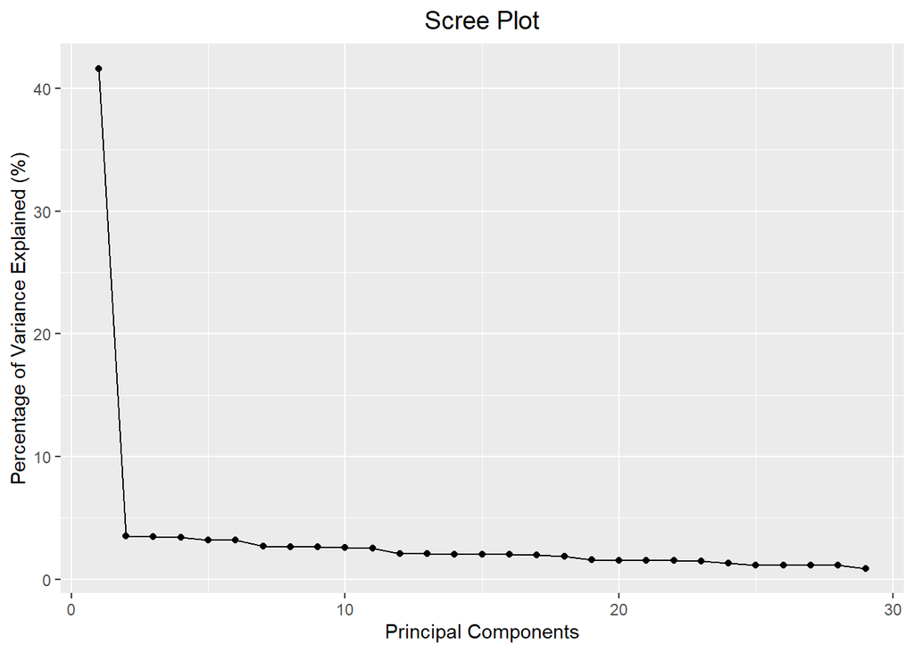

```r
# Scree plot
# Custom scree plot using ggplot2
pca_variance <- data.frame(
  PC = 1:length(pca_result$sdev),
  Variance = pca_result$sdev^2 / sum(pca_result$sdev^2) * 100
)
p3 <- ggplot(pca_variance, aes(x = PC, y = Variance)) +
  geom_line() +
  geom_point() +
  labs(title = "Scree Plot", x = "Principal Components", y = "Percentage of Variance Explained (%)") +
  theme(plot.title = element_text(hjust = 0.5, size = 14))

# Display scree plot
print(p3)
```

Nhận xét:

- PC1: Giải thích khoảng 40% phương sai.
- PC2 từ trở đi: Giảm mạnh xuống dưới mức 4% phương sai, đồ thị bắt đầu thoải ra. Phù hợp với nhận định ở trên là chỉ nên giữ lại 2 thành phần chính là PC1 và PC2.
- Điểm elbow có thể xác định là điểm PC2.

Bảng giá trị Loading của bộ dữ liệu.

```r
pca_loadings <- pca_result$rotation
print("PCA Loadings:")
```

```
## [1] "PCA Loadings:"
```

```r
print(pca_loadings)
```

```
##                                    PC1          PC2           PC3           PC4
## social_energy            -0.2354584797 -0.003230447  0.0089488402 -0.0042293311
## alone_time_preference     0.2377749517  0.007432720  0.0001628922  0.0147584702
## talkativeness            -0.2372408347  0.006574858  0.0037555831 -0.0048204969
## deep_reflection           0.2166162385 -0.001820952  0.0095025283  0.0206507891
## group_comfort            -0.2195160341 -0.013787039  0.0077433819 -0.0068214203
## party_liking             -0.2493799053 -0.005017505 -0.0075050892 -0.0023049277
## listening_skill           0.1468725243  0.014067368 -0.0564493072  0.0202680841
## empathy                   0.0801071331  0.059369963 -0.1686416276 -0.1037094559
## creativity               -0.0004821603 -0.595868071  0.5609243127  0.5309138296
## organization              0.1463626540 -0.006812303  0.0479412644 -0.0218985580
## leadership               -0.2188241182  0.003498648  0.0056999341  0.0085358383
## risk_taking              -0.2162371489 -0.005453788  0.0043354777 -0.0071092794
## public_speaking_comfort  -0.2369338572  0.008759231 -0.0018120175  0.0008787959
## curiosity                -0.0789811459  0.182968366 -0.0078833501  0.0501370454
## routine_preference        0.1896374154 -0.003830423  0.0214836475  0.0155830884
## excitement_seeking       -0.2361408472 -0.006016336  0.0064426953  0.0077796029
## friendliness             -0.1478245989 -0.013370500  0.0130007514  0.0163475041
## emotional_stability       0.0017478281 -0.696548820 -0.0999051163 -0.6861695288
## planning                  0.1453969364  0.028014436  0.0172714632  0.0334453077
## spontaneity              -0.1895430937  0.012875210  0.0050047836  0.0068856811
## adventurousness          -0.2180031878 -0.005368661 -0.0116719936  0.0002835990
## reading_habit             0.2184463722 -0.009105386  0.0066669262 -0.0066313027
## sports_interest          -0.1919115299  0.005687154 -0.0156160504  0.0099142558
## online_social_usage      -0.1888350443  0.003783110 -0.0240690467 -0.0203554800
## travel_desire            -0.1891205760 -0.010082285 -0.0045409474 -0.0010329808
## gadget_usage             -0.1476171313 -0.011465669 -0.0383898185  0.0045425790
## work_style_collaborative -0.1886869605 -0.016427512  0.0034867044 -0.0071158787
## decision_speed           -0.1909480023  0.015889926  0.0255022826 -0.0008063213
## stress_handling           0.0029519266  0.346372929  0.7980502933 -0.4794939811
##                                   PC5          PC6           PC7          PC8
## social_energy             0.017550985 -0.010384951 -0.0032912990 -0.017138566
## alone_time_preference    -0.017201923  0.016590026  0.0177071272  0.021212970
## talkativeness             0.003785184 -0.016930986 -0.0206211102 -0.017498024
## deep_reflection          -0.017153930  0.011455465 -0.0028409109  0.002180901
## group_comfort            -0.008479773 -0.022998927 -0.0045131721 -0.011942829
## party_liking              0.024780835 -0.011077792 -0.0119434377 -0.009636668
## listening_skill          -0.019588464  0.043563634 -0.1888332710  0.609126865
## empathy                  -0.073082742 -0.968366293 -0.0334008679  0.018114692
## creativity               -0.103524714 -0.182771005 -0.0338574773  0.033276127
```

[output cut: 185 more lines]

```
## routine_preference       -0.020922834
## excitement_seeking        0.133905346
## friendliness              0.009541914
## emotional_stability       0.001483087
## planning                 -0.009206637
## spontaneity               0.022584836
## adventurousness           0.039799944
## reading_habit            -0.040326739
## sports_interest           0.029597851
## online_social_usage       0.009321625
## travel_desire             0.013333427
## gadget_usage              0.003438040
## work_style_collaborative  0.011578981
## decision_speed            0.011919526
## stress_handling          -0.007741294
```

- PC1 (Thành phần chính đầu tiên)

social_energy: -0.2354584797 (âm, liên quan ngược).

alone_time_preference: 0.237749517 (dương, ưa thích thời gian một mình).

talkativeness: -0.2372408347 (âm, ít nói chuyện).

group_comfort: -0.2195160341 (âm, không thoải mái trong nhóm).

party_liking: -0.2493799053 (âm, không thích tiệc tùng).

listening_skill: 0.1468725243 (dương, nhẹ, kỹ năng lắng nghe).

Nhận xét: PC1 dường như đại diện cho xu hướng hướng nội (introversion) so với hướng ngoại (extraversion). Các biến như ưa thích thời gian một mình, suy ngẫm sâu, và không thoải mái trong nhóm có tải dương, trong khi năng lượng xã hội, nói chuyện, và thích tiệc tùng có tải âm.

- PC2 (Thành phần chính thứ hai)

Biến đóng góp lớn:

organization: -0.006812303 (gần 0, không ảnh hưởng).

```r
# View PCA scores (optional)
pca_scores <- pca_result$x
head(pca_scores)
```

```
##           PC1        PC2        PC3       PC4         PC5        PC6        PC7
## 1 -4.95088554  0.5999770  0.4891240 0.1444526  1.16149946 -0.4541800 -1.8357171
## 2  0.01836153 -0.1719671 -0.9336756 1.7688506  0.48429265  1.6325181  1.1703302
## 3  0.43470228 -0.3817053  0.1990563 0.6744847  0.08598068  0.1158613  0.2628600
## 4 -3.73767338 -1.5505420  0.5898213 0.5874661  0.58840015 -2.2308770  0.3072722
## 5  3.37129356 -1.7210118  0.1638305 2.2629694  0.43322822 -0.3670358 -0.3117337
## 6  4.06680688  0.3056074 -1.1750224 0.1984983 -0.01043970  1.3401845 -0.2985862
##         PC8        PC9       PC10        PC11       PC12        PC13       PC14
## 1 1.9358290 -0.5371730 -0.4299197  1.55695192 -1.1549798 -0.30526355  0.3409464
## 2 0.6454624 -0.4535676 -1.2101079  1.30177495  0.5101126  0.01908338 -0.5741130
## 3 0.7016451  0.4840763  1.2850327 -0.26389166  0.4532659 -0.29223068 -0.2042601
## 4 1.3664440  1.9984536  1.2224723 -0.08013082 -0.7255313 -1.48117896  0.2873330
## 5 0.4122888 -1.1201225 -0.4537878 -0.95157307 -0.5306182  0.79546227  0.2815894
## 6 1.3468900 -0.2970477 -2.1251530  0.63233064  0.7416351 -0.24276168  0.6202183
##         PC15        PC16        PC17       PC18        PC19        PC20
```

[output cut: 20 more lines]

- PC1 (Thành phần chính đầu tiên)

Quan sát nổi bật:

Dòng 1: -4.95088554 (rất âm, nổi bật ở hướng ngược).

Dòng 2: 0.01836153 (gần 0, trung bình).

Dòng 3: 0.43470228 (dương nhẹ).

Dòng 5: 3.37129356 (rất dương, nổi bật ở hướng thuận).

- PC2 (Thành phần chính thứ hai)

Quan sát nổi bật:

Dòng 1: 0.5999770 (dương nhẹ).

Dòng 5: -1.7210118 (âm, nổi bật).

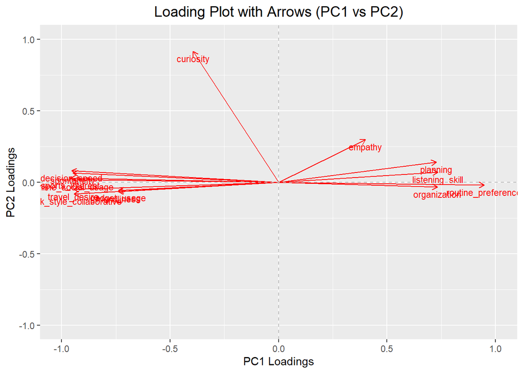

```r
# Loading plot for PC1 and PC2 with arrows
pca_loadings <- as.data.frame(pca_result$rotation[, 1:2]) # Extract loadings for PC1 and PC2
pca_loadings$variable <- rownames(pca_loadings)

# Scale loadings for better visualization (optional, adjust multiplier as needed)
pca_loadings$PC1 <- pca_loadings$PC1 * 5
pca_loadings$PC2 <- pca_loadings$PC2 * 5

p4 <- ggplot() +
  geom_segment(data = pca_loadings, aes(x = 0, y = 0, xend = PC1, yend = PC2),
               arrow = arrow(length = unit(0.2, "cm")), color = "red") +
  geom_text(data = pca_loadings, aes(x = PC1, y = PC2, label = variable),
            vjust = 1.5, hjust = 0.5, size = 3, color = "red") +
  geom_vline(xintercept = 0, linetype = "dashed", color = "gray") +
  geom_hline(yintercept = 0, linetype = "dashed", color = "gray") +
  labs(title = "Loading Plot with Arrows (PC1 vs PC2)", x = "PC1 Loadings", y = "PC2 Loadings") +
  theme(plot.title = element_text(hjust = 0.5, size = 14)) +
  xlim(-1, 1) + ylim(-1, 1) # Adjust limits based on scaled loadings

# Display loading plot
print(p4)
```

Nhận xét:

Biến có tải lớn trên PC1 (hướng ngang)

Biến âm (bên trái, PC1 < 0):

social_energy, talkativeness, party_liking, group_comfort: Các biến này có tải âm trên PC1, gợi ý PC1 phân biệt hướng ngoại (âm) so với hướng nội (dương). Những người có giá trị âm trên PC1 có xu hướng năng động xã hội.

Biến dương (bên phải, PC1 > 0):

alone_time_preference, deep_reflection: Các biến này có tải dương, liên quan đến xu hướng hướng nội, ưa thích thời gian một mình và suy ngẫm sâu.

Biến có tải lớn trên PC2 (hướng dọc)

Biến dương (trên, PC2 > 0):

Biến âm (dưới, PC2 < 0):

Biến có độ dài mũi tên lớn

Ý nghĩa: PC1 chủ yếu phân biệt hướng nội (introversion) và hướng ngoại (extraversion), trong khi PC2 liên quan đến khả năng cảm xúc, tổ chức, và tò mò. Điều này phù hợp với ma trận tải trước.

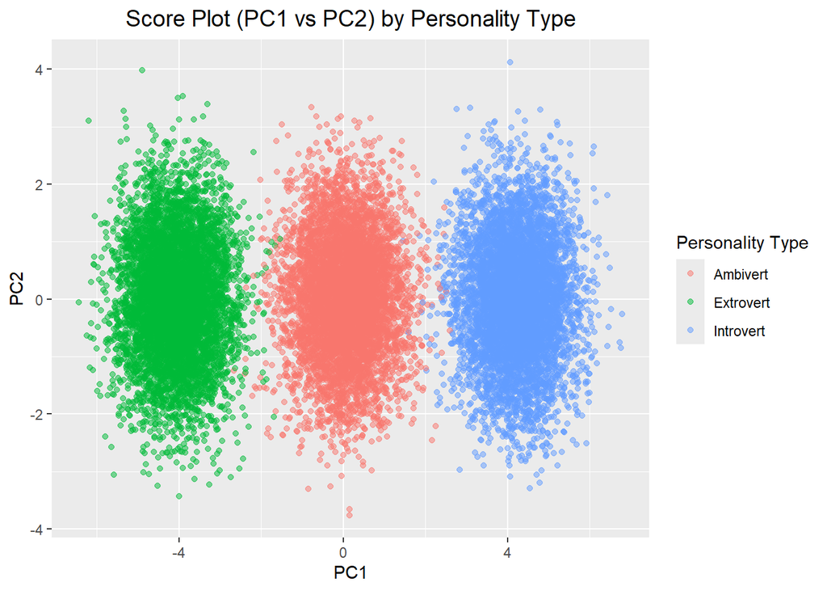

```r
# Score plot for PC1 and PC2 with personality_type
# Keep personality_type and sync with outliers
personality_types <- data$personality_type  # Get personality_type from original data
personality_types_no_outliers <- personality_types[-outliers]  # Remove outliers

pca_scores <- as.data.frame(pca_result$x)
pca_scores$personality_type <- personality_types_no_outliers  # Assign synced personality types

p5 <- ggplot(pca_scores, aes(x = PC1, y = PC2, color = personality_type)) +
  geom_point(alpha = 0.5) +
  labs(title = "Score Plot (PC1 vs PC2) by Personality Type",
       x = "PC1", y = "PC2", color = "Personality Type") +
  theme(plot.title = element_text(hjust = 0.5, size = 14)) +
  scale_color_discrete(name = "Personality Type")

# Display score plot
print(p5)
```

Nhận xét:

Phân biệt rõ ràng: PC1 phân biệt tốt ba nhóm tính cách:

Extravert (âm) vs Introvert (dương), với Ambivert ở giữa, xác nhận PC1 là trục hướng nội/hướng ngoại.

PC2 không phân biệt rõ ràng giữa các nhóm, nhưng cho thấy sự đa dạng nội bộ (ví dụ: Introvert có điểm cao trên PC2 có thể liên quan đến tò mò).

Trước khi phân tích nhân tố thì bộ dữ liệu xét phải được chuẩn hóa, nhưng hiện tại bộ dữ liệu chưa được scale nên ta thực hiện scale lại:

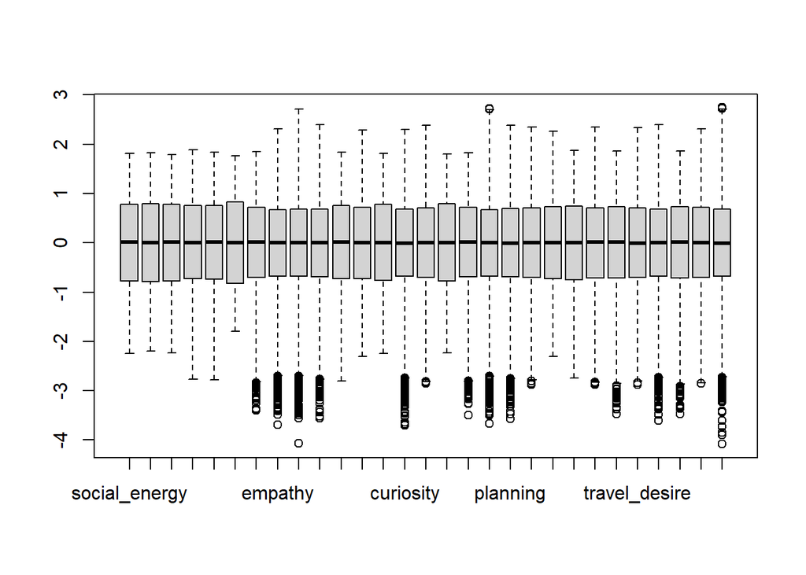

```r
data_sc <- scale(data_no_outliers, scale = T)
boxplot(data_sc)
```

**Nhận xét:** Bộ dữ liệu đã được chuẩn hóa, ta có thể tiến hành phân tích nhân tố FA

```r
fa.dat <- factanal(data_sc , factors = 2)
fa.dat
```

```
##
## Call:
## factanal(x = data_sc, factors = 2)
##
## Uniquenesses:
##            social_energy    alone_time_preference            talkativeness
##                    0.342                    0.328                    0.331
##          deep_reflection            group_comfort             party_liking
##                    0.451                    0.436                    0.249
##          listening_skill                  empathy               creativity
##                    0.760                    0.931                    1.000
##             organization               leadership              risk_taking
##                    0.763                    0.442                    0.453
##  public_speaking_comfort                curiosity       routine_preference
##                    0.331                    0.933                    0.591
##       excitement_seeking             friendliness      emotional_stability
##                    0.336                    0.750                    0.998
##                 planning              spontaneity          adventurousness
##                    0.746                    0.592                    0.446
##            reading_habit          sports_interest      online_social_usage
##                    0.442                    0.581                    0.593
##            travel_desire             gadget_usage work_style_collaborative
##                    0.593                    0.760                    0.593
##           decision_speed          stress_handling
##                    0.584                    1.000
##
## Loadings:
##                          Factor1 Factor2
## social_energy             0.808
## alone_time_preference    -0.816
## talkativeness             0.816
## deep_reflection          -0.732  -0.115
## group_comfort             0.742   0.116
## party_liking              0.862
## listening_skill          -0.482
## empathy                  -0.260
## creativity
## organization             -0.483
## leadership                0.743
## risk_taking               0.739
```

[output cut: 11 more lines]

```
## online_social_usage       0.637
## travel_desire             0.637
## gadget_usage              0.486
## work_style_collaborative  0.638
## decision_speed            0.644
## stress_handling
##
##                Factor1 Factor2
## SS loadings     11.489   0.155
## Proportion Var   0.396   0.005
## Cumulative Var   0.396   0.402
##
## Test of the hypothesis that 2 factors are sufficient.
## The chi square statistic is 376.5 on 349 degrees of freedom.
## The p-value is 0.149
```

**Nhận xét:** với giá trị p_value = 0.149 > 0.05 chứng tỏ không đủ cơ sở bác bỏ việc phân tích dựa trên 2 nhân tố là không thể hiện đầy đủ thông tin của bộ dữ liệu. Vì vậy ta nhận việc phân tích bộ dữ liệu dựa trên 2 nhân tố.

**KIỂM TRA ĐỘ CUNG CẤP THÔNG TIN CHO NHÂN TỐ**

```r
round(1 - fa.dat$uniquenesses,3)
```

```
##            social_energy    alone_time_preference            talkativeness
##                    0.658                    0.672                    0.669
##          deep_reflection            group_comfort             party_liking
##                    0.549                    0.564                    0.751
##          listening_skill                  empathy               creativity
##                    0.240                    0.069                    0.000
##             organization               leadership              risk_taking
##                    0.237                    0.558                    0.547
##  public_speaking_comfort                curiosity       routine_preference
##                    0.669                    0.067                    0.409
##       excitement_seeking             friendliness      emotional_stability
##                    0.664                    0.250                    0.002
##                 planning              spontaneity          adventurousness
##                    0.254                    0.408                    0.554
##            reading_habit          sports_interest      online_social_usage
##                    0.558                    0.419                    0.407
##            travel_desire             gadget_usage work_style_collaborative
##                    0.407                    0.240                    0.407
##           decision_speed          stress_handling
##                    0.416                    0.000
```

**Nhận xét:**

- đây là các biến có hệ số lớn, có nghĩa chúng chia sẻ rất nhiều phương sai của nó với các biến khác: social_energy,alone_time_preference, talkativeness, deep_reflection , group_comfort, party_liking, leadership, risk_taking, public_speaking_comfort, excitement_seeking, adventurousness. reading_habit.
- nhưng có một số biến gần như bằng 0 như là stress_handling, creativity, emotional_stability,empathy. gần như chúng không chia sẻ bất cứ một thông tin nào. vì có sự chênh lệch như vậy nên ta sẽ thử xoay nhân tố theo “varimax” xem thử có thay đổi chút gì được không.

```r
fa.dat <- factanal(data_sc, factors = 2)
fa.dat
```

```
##
## Call:
## factanal(x = data_sc, factors = 2)
##
## Uniquenesses:
##            social_energy    alone_time_preference            talkativeness
##                    0.342                    0.328                    0.331
##          deep_reflection            group_comfort             party_liking
##                    0.451                    0.436                    0.249
##          listening_skill                  empathy               creativity
##                    0.760                    0.931                    1.000
##             organization               leadership              risk_taking
##                    0.763                    0.442                    0.453
##  public_speaking_comfort                curiosity       routine_preference
##                    0.331                    0.933                    0.591
##       excitement_seeking             friendliness      emotional_stability
##                    0.336                    0.750                    0.998
##                 planning              spontaneity          adventurousness
##                    0.746                    0.592                    0.446
##            reading_habit          sports_interest      online_social_usage
##                    0.442                    0.581                    0.593
##            travel_desire             gadget_usage work_style_collaborative
##                    0.593                    0.760                    0.593
##           decision_speed          stress_handling
##                    0.584                    1.000
##
## Loadings:
##                          Factor1 Factor2
## social_energy             0.808
## alone_time_preference    -0.816
## talkativeness             0.816
## deep_reflection          -0.732  -0.115
## group_comfort             0.742   0.116
## party_liking              0.862
## listening_skill          -0.482
## empathy                  -0.260
## creativity
## organization             -0.483
## leadership                0.743
## risk_taking               0.739
```

[output cut: 11 more lines]

```
## online_social_usage       0.637
## travel_desire             0.637
## gadget_usage              0.486
## work_style_collaborative  0.638
## decision_speed            0.644
## stress_handling
##
##                Factor1 Factor2
## SS loadings     11.489   0.155
## Proportion Var   0.396   0.005
## Cumulative Var   0.396   0.402
##
## Test of the hypothesis that 2 factors are sufficient.
## The chi square statistic is 376.5 on 349 degrees of freedom.
## The p-value is 0.149
```

```r
round(1 - fa.dat$uniquenesses,3)
```

```
##            social_energy    alone_time_preference            talkativeness
##                    0.658                    0.672                    0.669
##          deep_reflection            group_comfort             party_liking
##                    0.549                    0.564                    0.751
##          listening_skill                  empathy               creativity
##                    0.240                    0.069                    0.000
##             organization               leadership              risk_taking
##                    0.237                    0.558                    0.547
##  public_speaking_comfort                curiosity       routine_preference
##                    0.669                    0.067                    0.409
##       excitement_seeking             friendliness      emotional_stability
##                    0.664                    0.250                    0.002
##                 planning              spontaneity          adventurousness
##                    0.254                    0.408                    0.554
##            reading_habit          sports_interest      online_social_usage
##                    0.558                    0.419                    0.407
##            travel_desire             gadget_usage work_style_collaborative
##                    0.407                    0.240                    0.407
##           decision_speed          stress_handling
##                    0.416                    0.000
```

**Nhận xét:** Sau khi xoay ta cũng không nhận lại được gì nhiều thay đổi nên vì vậy ta sẽ phân tích hệ số tải của FA luôn.

```r
fa.dat$loadings
```

```
##
## Loadings:
##                          Factor1 Factor2
## social_energy             0.808
## alone_time_preference    -0.816
## talkativeness             0.816
## deep_reflection          -0.732  -0.115
## group_comfort             0.742   0.116
## party_liking              0.862
## listening_skill          -0.482
## empathy                  -0.260
## creativity
## organization             -0.483
## leadership                0.743
## risk_taking               0.739
## public_speaking_comfort   0.817
## curiosity                 0.259
## routine_preference       -0.639
## excitement_seeking        0.813
## friendliness              0.480   0.138
## emotional_stability
## planning                 -0.467  -0.189
## spontaneity               0.637
## adventurousness           0.742
## reading_habit            -0.740
## sports_interest           0.645
## online_social_usage       0.637
## travel_desire             0.637
## gadget_usage              0.486
## work_style_collaborative  0.638
## decision_speed            0.644
## stress_handling
##
##                Factor1 Factor2
## SS loadings     11.489   0.155
## Proportion Var   0.396   0.005
## Cumulative Var   0.396   0.402
```

**Nhận xét:**

- Ở factor 1:
  - các biến có hệ số lớn hơn 0 như là: social_energy,talkativeness,group_comfort, party_liking, leadership,risk_taking,public_speaking_comfort,curiosity, excitement_seeking,friendliness ,spontaneity, adventurousness,sports_interest ,online_social_usage, travel_desire,gadget_usage, work_style_collaborative, decision_speed
  - Các biến có hệ số < 0: alone_time_preference, deep_reflection, listening_skill, empathy, organization, routine_preference, routine_preference, planning, reading_habit, stress_handling => đây là những tính cách thể hiện một người có tính cách hương ngoại và đối lập với điều đó là một người hướng nội Từ đây ta có thể thấy factor 1 chính là đại diện nhân tố của một người hương ngoại và để dễ dàng nhận biết và phân biệt với một người hướng nội
- Ở Factor 2:
  - Biến có hệ số >0: group_comfort, friendliness
  - Biến có hệ số <0: deep_reflection, planning => Đây là nhóm tính cách vừa có một chút của hướng ngoại là thoải mái trong nhóm, thân thiện nhưng cũng có chút của hương nội là suy nghĩ nội tâm, lập kế hoạch. Từ đây ta có thế thấy factor 2 chính là nhân tố ẩn của một người khi họ vừa có chút tính cách hướng ngoại vừa có chút tính cách hướng nội hay còn gọi với một cái tên là Ambiver (người trung tính), là sự kết hợp giữa một chút hướng ngoại một chút hướng nội: đây là người có sự hòa đồng, thân thiện nhưng lại có cái nhìn rất sâu sắc đôi khi và bộ dữ liệu đã thể hiện đây là một người vừa có yếu tố xã hội vừa có yếu tố nội tâm. mặc ù là hệ số của cả 4 biến không quá cao nhưng đâu đó ta có thể nhận dạng được sự pha trộn này.